## Question

Exercises 3.4, 3.5, 3.7, 3.11, 3.12 (pages 96-97, Statistical Computing with R, 2nd edition).

## 1 问题一（3.4）

3.4 The Rayleigh density [162, Ch, 18]is
$$f(x) = \frac{x}{\sigma^2} e^{-x^2/(2\sigma^2)}, \quad x \geq 0, \sigma
> 0.$$

Develop an algorithm to generate random samples from a Rayleigh(σ) distribution. Generate Rayleigh(σ) samples for several choices of σ > 0 and check that the mode of the generated samples is close to the theoretical mode σ (check the histogram).

### 1.1 问题分析

这个问题可以拆分为两部分：

1、已知一个瑞利函数，编写算法，生成一组数据满足这个分布； 使用R语言开发数据生成代码，其中，逆变换法是生成随机样本的一种常见的方法。 瑞利分布的累积分布函数（CDF）的逆函数可以显式写出，因此本模块采用“逆变换法”生成瑞利随机数。

2、通过直方图验证我生成的数据是否满足这个分布。 直方图是一种快速目测的手段，此处并非证明，目的是进行快速验证。

### 1.2 定义瑞利分布样本生成函数

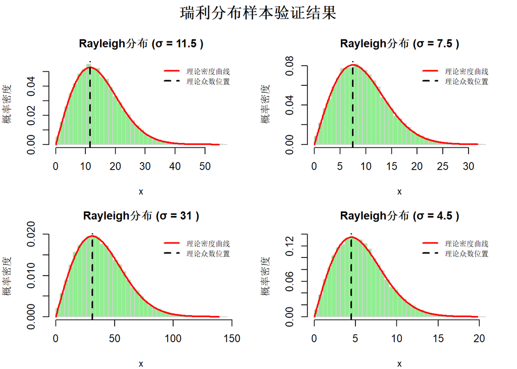

```
##            瑞利分布样本统计验证结果
```

```
##   Sigma 理论众数 经验众数 众数差异 理论均值 样本均值 理论标准差 样本标准差
## 1  11.5     11.5   10.960    0.540   14.413   14.435      7.534      7.496
## 2   7.5      7.5    8.069    0.569    9.400    9.435      4.914      4.913
## 3  31.0     31.0   29.160    1.840   38.853   38.846     20.309     20.359
## 4   4.5      4.5    4.489    0.011    5.640    5.652      2.948      2.938
```

### 1.3 结果分析

算法生成效果符合预期,验证结论。

## 2 问题二（3.5）

3.5 A discrete random variable X has probability mass function

$$\begin{array}{c|ccccc}
x & 0 & 1 & 2 & 3 & 4\\
\hline
p(x) & 0.1 & 0.2 & 0.2 & 0.2 & 0.3\\
\end{array}$$

Use the inverse transform method to generaate a random sample of size 1000 from the distribution of X. Construct a relative frequency table and compare the emporocal with the theoretical probability. Repeat using the R sample function.

### 2.1 问题分析

该问题与3.4相似：

1、需要先使用逆变换法生成离散随机变量X得随机样本（1000个）

2、将经验概率与理论概率进行比较（构建相对频率表）。两次比较：第一次逆变换法比较、第二次sample函数比较。

### 2.2 生成样本并构建相对频率表

```
## 逆变换方法 - 理论概率与经验概率比较:
```

```
##   x theoretical empirical difference
## 1 0         0.1     0.093      0.007
## 2 1         0.2     0.186      0.014
## 3 2         0.2     0.221      0.021
## 4 3         0.2     0.187      0.013
## 5 4         0.3     0.313      0.013
```

```
##
## Sample函数 - 理论概率与经验概率比较:
```

```
##   x theoretical empirical difference
## 1 0         0.1     0.109      0.009
## 2 1         0.2     0.218      0.018
## 3 2         0.2     0.179      0.021
## 4 3         0.2     0.213      0.013
## 5 4         0.3     0.281      0.019
```

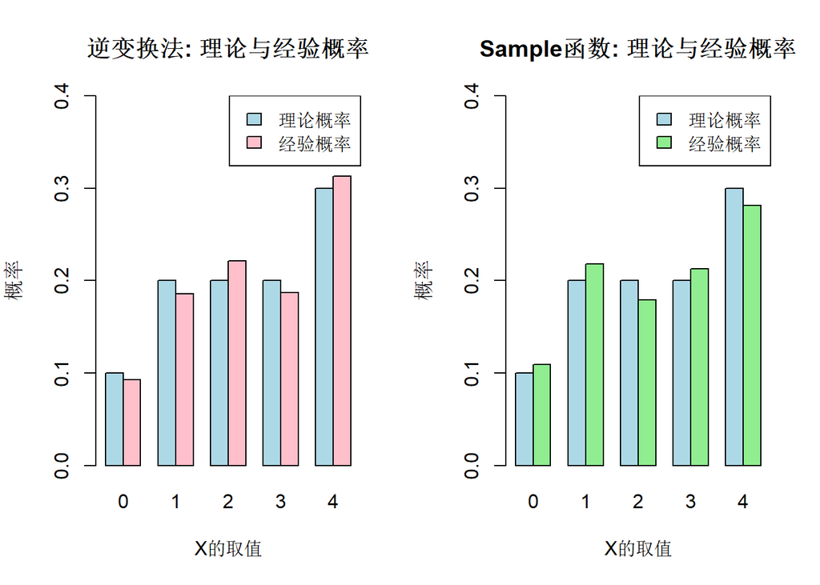

### 2.3 结果分析

两种方法生成的经验概率和理论概率都十分吻合，验证了两种抽样方法的有效性。

## 3 问题三（3.7）

3.7 Write a function to generate a random sample of size n from the Beta(a,b) distribution by the acceptance-rejection method. Generate a random sample of size 1000 from the Beta(3,2) distribution. Graph the histogram of the sample with the theoretical Beta(3,2) density superimposed.

### 3.1 问题分析

1、编写函数，生成Beta(a,b)分布的随机样本

2、使用该函数生成Beta(3,2)分布的1000个随机样本

3、绘制直方图验证正确性

### 3.2 编写Beta分布代码并绘制直方图

```
## === 抽样效率分析 ===
```

```
## 接受率: 71.33%
```

```
## 常数c值: 1.3333
```

```
## 提议分布: Beta(2,2)
```

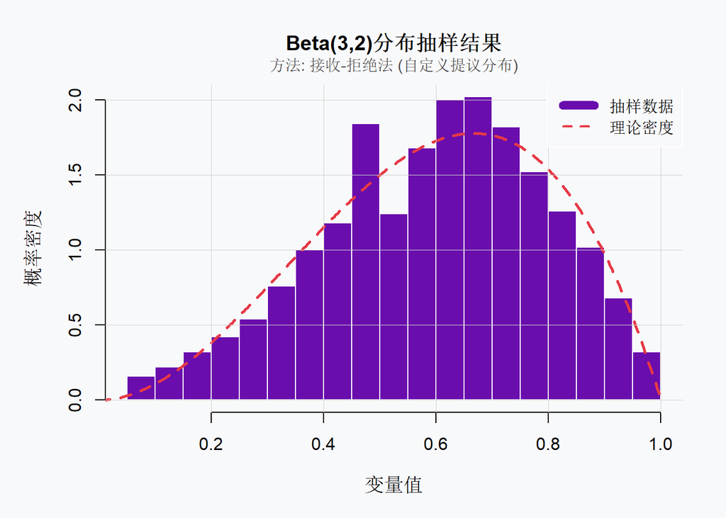

### 3.3 结果分析

从71.33%的接受率、高度吻合的密度曲线，可以看出接收-拒绝法实现了高效准确的Beta(3,2)分布抽样，可以反映理论分布的特性。

## 4 问题四（3.11）

3.11 Generate a random sample of size 1000 from a normal location mixture. The components of the mixture have N(0,1) and N(3,1) distributions with mixing probabilities p1 and p2 == 1 - p1. Graph the histogram of the sample with density superimposed, for p1 = 0.75. Repeat with different values for p1 and observe whether the empirical distribution of the mixture appears to be bimodal. Make a conjecture about the values of p1 that produce bimodal mixtures.

### 4.1 问题分析

该问题主要需要做以下任务：

1、构建“正态位置混合分布”

2、可视化直方图并进行验证

3、尝试不同的p1取值，推测p1在什么范围内，呈现双峰形态。

### 4.2 P多次赋值并绘制直方图

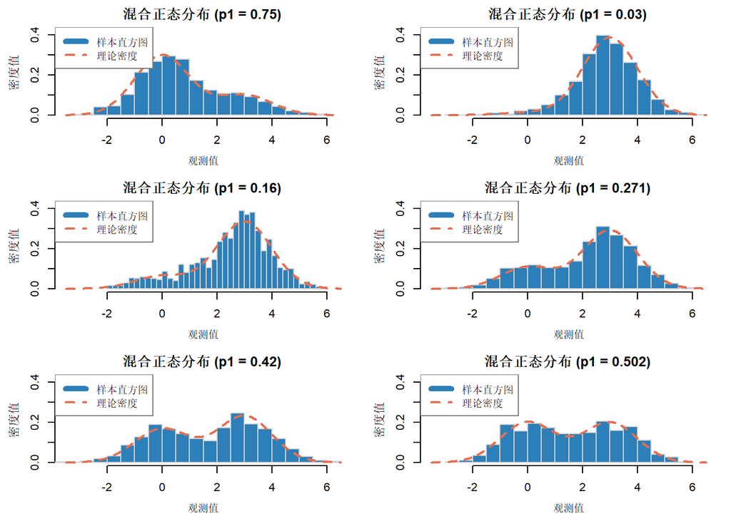

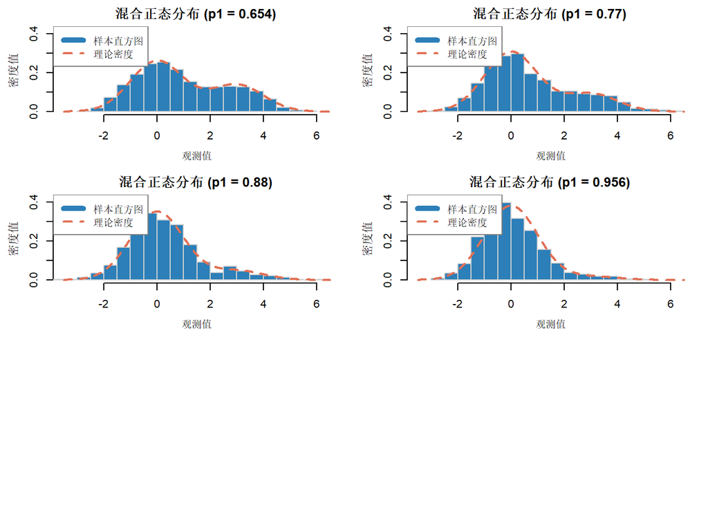

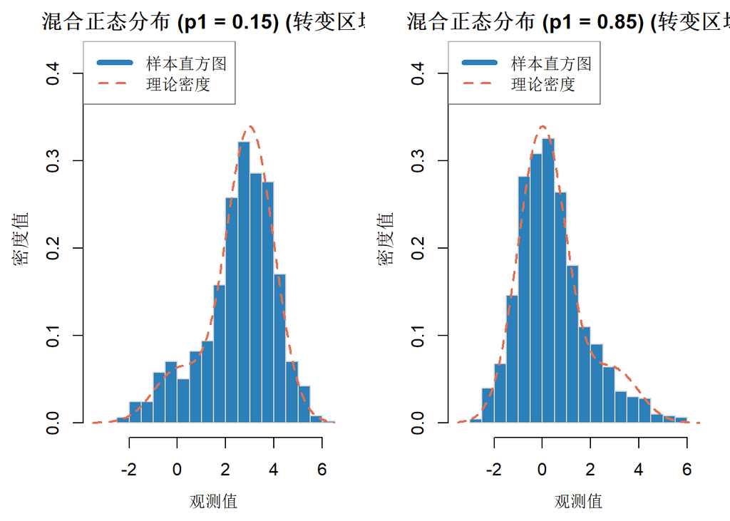

### 4.3 结果分析

当P1值取在0.2-0.8之间，分布呈现双峰特征。

当p1小于0.2或大于0.8时，呈现单峰，且分别向两侧偏移。

## 5 问题五（3.12）

3.12 Simulate a continuous Exponential-Gamma mixture. Suppose that the rate parameter Λ has Gamma(r,β) distribution and Y has Exp(Λ) distribution. That is,

$$(Y|Λ=λ)~f_{Y}(y|λ) = λe^{-λy}$$

Generate 1000 random observations from this mixture with r=4 and β=2.

### 5.1 问题分析

从gamma分布生成1000个样本，对每个生成的lambda，生成观测值。

### 5.2 样本生成、绘制直方图

```
## [1] 0.0541792519 0.4447527922 0.1219373098 0.2337652649 0.0006396861
## [6] 0.0075582215
```

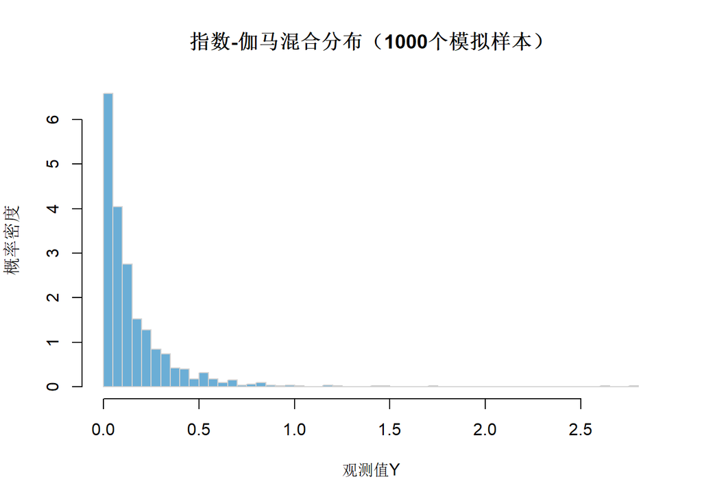